# Parsing XML

## Co-Occurrence and Correlation Matrixes

Now that we have this large dataframe that has the 424 unique code elements and the number of times each attribute value appeared in that element, we can create matrixes and better capture how often particular attribute values appeared together!

Specifically, the adjacency matrix (df.T.dot(df) shows a raw count of when particular attribute values were used together. This will be especially useful when talking about the relationship between writing, motivation, uptake, genre, and how fans interpret the canonical text.

```python
#correlation matrix
corr = df.corr()
corr
```

| values | LGBTQplus | abelism | angst | antiracism | audience | authors-note | canon-compliant | canon-compliment | canon-critique | canon-relation | ... | modern-setting | motivation | other | racism | reception | reflection | research | revising | sexism | vignette |
| --- | --- | --- | --- | --- | --- | --- | --- | --- | --- | --- | --- | --- | --- | --- | --- | --- | --- | --- | --- | --- | --- |
| LGBTQplus | 1.000000 | -0.032359 | -0.042961 | -0.045982 | -0.068834 | -0.042961 | 0.028181 | 0.035259 | -0.039765 | 0.125968 | ... | 0.038625 | 0.089026 | -0.094738 | -0.056589 | -0.079412 | 0.078040 | -0.017090 | -0.036222 | -0.048830 | -0.051534 |
| abelism | -0.032359 | 1.000000 | -0.012644 | -0.013533 | -0.028815 | -0.012644 | -0.027409 | -0.026443 | 0.150853 | -0.020548 | ... | -0.016655 | 0.029512 | -0.027883 | -0.016655 | -0.023372 | 0.026193 | 0.118505 | -0.010661 | -0.014372 | -0.015167 |
| angst | -0.042961 | -0.012644 | 1.000000 | -0.017967 | -0.038255 | -0.016787 | -0.036389 | -0.035106 | -0.038255 | -0.027281 | ... | -0.022112 | -0.053112 | 0.103122 | -0.022112 | -0.031029 | -0.055130 | -0.023942 | -0.014153 | -0.019080 | -0.020136 |
| antiracism | -0.045982 | -0.013533 | -0.017967 | 1.000000 | 0.022881 | -0.017967 | -0.038948 | 0.031097 | 0.022881 | -0.029199 | ... | -0.023667 | 0.041937 | -0.039621 | -0.023667 | -0.033212 | 0.037220 | 0.071385 | -0.015149 | -0.020422 | -0.021553 |
| audience | -0.068834 | -0.028815 | -0.038255 | 0.022881 | 1.000000 | 0.029897 | -0.049567 | -0.080003 | -0.087179 | -0.062170 | ... | -0.050391 | -0.096293 | -0.084360 | -0.050391 | -0.032372 | -0.077429 | -0.054561 | -0.032254 | -0.043481 | 0.068563 |
| authors-note | -0.042961 | -0.012644 | -0.016787 | -0.017967 | 0.029897 | 1.000000 | -0.036389 | -0.035106 | -0.038255 | -0.027281 | ... | -0.022112 | -0.000373 | -0.037018 | -0.022112 | -0.031029 | 0.047618 | -0.023942 | -0.014153 | -0.019080 | -0.020136 |
| canon-compliant | 0.028181 | -0.027409 | -0.036389 | -0.038948 | -0.049567 | -0.036389 | 1.000000 | 0.031574 | -0.082926 | 0.075670 | ... | 0.006700 | 0.013942 | -0.080245 | 0.006700 | -0.027264 | -0.069213 | -0.001196 | -0.030681 | -0.041360 | 0.016052 |
| canon-compliment | 0.035259 | -0.026443 | -0.035106 | 0.031097 | -0.080003 | -0.035106 | 0.031574 | 1.000000 | -0.080003 | -0.057052 | ... | -0.046243 | -0.031206 | -0.042045 | -0.046243 | -0.064892 | -0.115295 | -0.050069 | -0.029599 | 0.089742 | -0.042111 |
| canon-critique | -0.039765 | 0.150853 | -0.038255 | 0.022881 | -0.087179 | -0.038255 | -0.082926 | -0.080003 | 1.000000 | -0.019098 | ... | -0.050391 | 0.126406 | -0.018609 | 0.106709 | -0.070713 | -0.125637 | -0.054561 | -0.032254 | 0.137265 | -0.045889 |
| canon-relation | 0.125968 | -0.020548 | -0.027281 | -0.029199 | -0.062170 | -0.027281 | 0.075670 | -0.057052 | -0.019098 | 1.000000 | ... | -0.035935 | 0.113671 | -0.060160 | 0.105143 | -0.050427 | -0.089595 | -0.038909 | -0.023001 | -0.031008 | -0.032725 |
| canon-resistant | 0.080819 | 0.096788 | -0.028063 | -0.030036 | 0.019997 | -0.028063 | -0.060832 | -0.058688 | 0.061972 | -0.045606 | ... | 0.031777 | 0.073621 | -0.018728 | -0.036965 | -0.051873 | 0.002761 | -0.040024 | -0.023661 | -0.031897 | 0.041458 |
| class | -0.027991 | -0.008238 | -0.010937 | -0.011706 | -0.024925 | -0.010937 | 0.084382 | -0.022873 | -0.024925 | -0.017774 | ... | -0.014407 | 0.045572 | 0.082405 | 0.155271 | -0.020217 | 0.042182 | -0.015599 | -0.009221 | -0.012431 | -0.013120 |
| critical-uptake | 0.006519 | 0.054793 | -0.040652 | 0.259919 | -0.062239 | -0.040652 | -0.088122 | -0.085016 | 0.150578 | -0.025112 | ... | -0.053548 | 0.130174 | 0.191677 | -0.003758 | -0.075143 | -0.018918 | -0.057979 | -0.034275 | -0.046206 | -0.048764 |
| cultural-difference | 0.017549 | -0.024428 | -0.032431 | -0.034712 | -0.037041 | 0.046145 | 0.045084 | 0.011507 | -0.037041 | 0.245257 | ... | -0.042719 | -0.074082 | -0.071518 | 0.078034 | -0.059948 | 0.115818 | -0.046255 | -0.027344 | -0.036862 | -0.038903 |
| disability | -0.030661 | 0.221466 | -0.027281 | -0.029199 | -0.062170 | -0.027281 | 0.030734 | -0.010711 | 0.023974 | 0.129721 | ... | -0.035935 | 0.113671 | 0.072693 | -0.035935 | -0.050427 | 0.105216 | 0.157487 | 0.085360 | -0.031008 | -0.032725 |
| drafting | -0.051534 | -0.015167 | -0.020136 | -0.021553 | -0.045889 | 0.101832 | -0.043650 | -0.042111 | -0.045889 | -0.032725 | ... | -0.026524 | -0.063711 | -0.044405 | -0.026524 | -0.037221 | -0.066132 | -0.028719 | -0.016978 | -0.022887 | 0.078261 |
| fan-politics | 0.085828 | -0.058825 | -0.036235 | -0.005178 | 0.116645 | -0.078098 | -0.066838 | -0.142195 | -0.099412 | -0.074006 | ... | -0.006373 | -0.171101 | 0.029720 | 0.090128 | -0.050157 | -0.226877 | -0.081533 | -0.065847 | -0.014751 | -0.093683 |
| fan-practices-uptake | -0.046579 | -0.030175 | -0.040061 | 0.018542 | 0.124099 | -0.040061 | -0.054740 | -0.050675 | -0.091296 | -0.023657 | ... | -0.002377 | 0.016118 | -0.088344 | -0.002377 | 0.036634 | -0.131569 | -0.010368 | -0.033777 | -0.045535 | 0.007014 |
| feminism | -0.041975 | -0.022830 | -0.030310 | 0.045713 | -0.069073 | -0.030310 | -0.065703 | 0.315742 | -0.029919 | 0.003483 | ... | -0.039925 | 0.055595 | 0.013672 | -0.039925 | -0.056026 | 0.018516 | -0.043229 | -0.025555 | 0.039322 | -0.036358 |
| fix-it | -0.032359 | -0.009524 | -0.012644 | -0.013533 | -0.028815 | -0.012644 | -0.027409 | -0.026443 | 0.061019 | -0.020548 | ... | -0.016655 | 0.099029 | -0.027883 | -0.016655 | 0.084343 | -0.041525 | -0.018033 | -0.010661 | -0.014372 | -0.015167 |
| fluff | 0.115488 | -0.014372 | 0.237743 | -0.020422 | -0.043481 | -0.019080 | -0.041360 | -0.039902 | -0.043481 | -0.031008 | ... | -0.025133 | 0.032878 | -0.042075 | -0.025133 | -0.035269 | -0.017246 | -0.027213 | -0.016087 | -0.021687 | -0.022887 |
| genre-other | -0.006380 | -0.022830 | 0.053140 | -0.032441 | 0.009234 | -0.030310 | 0.015992 | -0.063387 | -0.069073 | -0.049257 | ... | -0.039925 | -0.065599 | -0.026584 | -0.039925 | -0.009079 | 0.018516 | -0.043229 | -0.025555 | -0.034450 | -0.036358 |
| heteronormativity | -0.012892 | -0.023905 | -0.031736 | -0.033968 | -0.034744 | -0.031736 | -0.029589 | -0.025938 | 0.002836 | -0.051576 | ... | 0.019741 | -0.071331 | -0.069985 | -0.041804 | -0.058663 | -0.047571 | -0.045263 | -0.026758 | 0.105545 | -0.038069 |
| homophobia-transphobia | -0.004451 | -0.015927 | -0.021145 | -0.022632 | 0.061071 | 0.095289 | -0.045836 | -0.044220 | -0.048187 | 0.039223 | ... | -0.027852 | -0.024627 | -0.046629 | -0.027852 | -0.039085 | 0.012917 | 0.052873 | -0.017828 | -0.024034 | -0.025364 |
| identity-bending | 0.260614 | -0.015167 | -0.020136 | -0.021553 | -0.045889 | -0.020136 | -0.043650 | -0.042111 | -0.045889 | -0.032725 | ... | 0.160913 | 0.024858 | -0.044405 | 0.067195 | -0.037221 | 0.063283 | -0.028719 | -0.016978 | -0.022887 | -0.024155 |
| implicit-explicit | 0.017549 | -0.024428 | -0.032431 | -0.034712 | -0.073908 | -0.032431 | -0.031840 | 0.011507 | -0.073908 | -0.052706 | ... | 0.138411 | 0.040035 | 0.042196 | -0.042719 | -0.059948 | -0.050928 | -0.046255 | -0.027344 | 0.032603 | -0.038903 |
| modern-setting | 0.038625 | -0.016655 | -0.022112 | -0.023667 | -0.050391 | -0.022112 | 0.006700 | -0.046243 | -0.050391 | -0.035935 | ... | 1.000000 | -0.069961 | -0.048761 | -0.029126 | -0.040873 | -0.033144 | -0.031537 | -0.018643 | 0.073536 | -0.026524 |
| motivation | 0.089026 | 0.029512 | -0.053112 | 0.041937 | -0.096293 | -0.000373 | 0.013942 | -0.031206 | 0.126406 | 0.113671 | ... | -0.069961 | 1.000000 | 0.035521 | -0.069961 | -0.098176 | -0.174430 | -0.075750 | -0.044781 | -0.060368 | -0.019426 |
| other | -0.094738 | -0.027883 | 0.103122 | -0.039621 | -0.084360 | -0.037018 | -0.080245 | -0.042045 | -0.018609 | -0.060160 | ... | -0.048761 | 0.035521 | 1.000000 | 0.005079 | -0.068426 | 0.027120 | 0.147076 | 0.051498 | 0.081813 | -0.044405 |
| racism | -0.056589 | -0.016655 | -0.022112 | -0.023667 | -0.050391 | -0.022112 | 0.006700 | -0.046243 | 0.106709 | 0.105143 | ... | -0.029126 | -0.069961 | 0.005079 | 1.000000 | 0.021917 | -0.033144 | -0.031537 | -0.018643 | -0.025133 | -0.026524 |
| reception | -0.079412 | -0.023372 | -0.031029 | -0.033212 | -0.032372 | -0.031029 | -0.027264 | -0.064892 | -0.070713 | -0.050427 | ... | -0.040873 | -0.098176 | -0.068426 | 0.021917 | 1.000000 | -0.101906 | -0.044255 | -0.026162 | -0.035269 | -0.037221 |
| reflection | 0.078040 | 0.026193 | -0.055130 | 0.037220 | -0.077429 | 0.047618 | -0.069213 | -0.115295 | -0.125637 | -0.089595 | ... | -0.033144 | -0.174430 | 0.027120 | -0.033144 | -0.101906 | 1.000000 | -0.078629 | -0.046482 | -0.017246 | -0.022993 |
| research | -0.017090 | 0.118505 | -0.023942 | 0.071385 | -0.054561 | -0.023942 | -0.001196 | -0.050069 | -0.054561 | -0.038909 | ... | -0.031537 | -0.075750 | 0.147076 | -0.031537 | -0.044255 | -0.078629 | 1.000000 | 0.102083 | -0.027213 | 0.058259 |
| revising | -0.036222 | -0.010661 | -0.014153 | -0.015149 | -0.032254 | -0.014153 | -0.030681 | -0.029599 | -0.032254 | -0.023001 | ... | -0.018643 | -0.044781 | 0.051498 | -0.018643 | -0.026162 | -0.046482 | 0.102083 | 1.000000 | -0.016087 | -0.016978 |
| sexism | -0.048830 | -0.014372 | -0.019080 | -0.020422 | -0.043481 | -0.019080 | -0.041360 | 0.089742 | 0.137265 | -0.031008 | ... | 0.073536 | -0.060368 | 0.081813 | -0.025133 | -0.035269 | -0.017246 | -0.027213 | -0.016087 | 1.000000 | -0.022887 |
| vignette | -0.051534 | -0.015167 | -0.020136 | -0.021553 | 0.068563 | -0.020136 | 0.016052 | -0.042111 | -0.045889 | -0.032725 | ... | -0.026524 | -0.019426 | -0.044405 | -0.026524 | -0.037221 | -0.022993 | 0.058259 | -0.016978 | -0.022887 | 1.000000 |

36 rows × 36 columns

```python
strong_pairs = corr[abs(corr) > 0.10]
print(strong_pairs)
```

```
values                  LGBTQplus   abelism     angst  antiracism  audience  \
values
LGBTQplus                1.000000       NaN       NaN         NaN       NaN
abelism                       NaN  1.000000       NaN         NaN       NaN
angst                         NaN       NaN  1.000000         NaN       NaN
antiracism                    NaN       NaN       NaN    1.000000       NaN
audience                      NaN       NaN       NaN         NaN  1.000000
authors-note                  NaN       NaN       NaN         NaN       NaN
canon-compliant               NaN       NaN       NaN         NaN       NaN
canon-compliment              NaN       NaN       NaN         NaN       NaN
canon-critique                NaN  0.150853       NaN         NaN       NaN
canon-relation           0.125968       NaN       NaN         NaN       NaN
canon-resistant               NaN       NaN       NaN         NaN       NaN
class                         NaN       NaN       NaN         NaN       NaN
critical-uptake               NaN       NaN       NaN    0.259919       NaN
cultural-difference           NaN       NaN       NaN         NaN       NaN
disability                    NaN  0.221466       NaN         NaN       NaN
drafting                      NaN       NaN       NaN         NaN       NaN
fan-politics                  NaN       NaN       NaN         NaN  0.116645
fan-practices-uptake          NaN       NaN       NaN         NaN  0.124099
feminism                      NaN       NaN       NaN         NaN       NaN
fix-it                        NaN       NaN       NaN         NaN       NaN
fluff                    0.115488       NaN  0.237743         NaN       NaN
genre-other                   NaN       NaN       NaN         NaN       NaN
heteronormativity             NaN       NaN       NaN         NaN       NaN
homophobia-transphobia        NaN       NaN       NaN         NaN       NaN
identity-bending         0.260614       NaN       NaN         NaN       NaN
implicit-explicit             NaN       NaN       NaN         NaN       NaN
modern-setting                NaN       NaN       NaN         NaN       NaN
motivation                    NaN       NaN       NaN         NaN       NaN
other                         NaN       NaN  0.103122         NaN       NaN
racism                        NaN       NaN       NaN         NaN       NaN
reception                     NaN       NaN       NaN         NaN       NaN
reflection                    NaN       NaN       NaN         NaN       NaN
research                      NaN  0.118505       NaN         NaN       NaN
revising                      NaN       NaN       NaN         NaN       NaN
sexism                        NaN       NaN       NaN         NaN       NaN
vignette                      NaN       NaN       NaN         NaN       NaN

values                  authors-note  canon-compliant  canon-compliment  \
```

[output cut: 141 more lines]

```
homophobia-transphobia       NaN       NaN       NaN       NaN
identity-bending             NaN       NaN       NaN       NaN
implicit-explicit            NaN       NaN       NaN       NaN
modern-setting               NaN       NaN       NaN       NaN
motivation                   NaN       NaN       NaN       NaN
other                   0.147076       NaN       NaN       NaN
racism                       NaN       NaN       NaN       NaN
reception                    NaN       NaN       NaN       NaN
reflection                   NaN       NaN       NaN       NaN
research                1.000000  0.102083       NaN       NaN
revising                0.102083  1.000000       NaN       NaN
sexism                       NaN       NaN  1.000000       NaN
vignette                     NaN       NaN       NaN       1.0

[36 rows x 36 columns]
```

```python
#Adjacency/co-occurance matrix!!!

coocc = df.T.dot(df)
coocc
```

| values | LGBTQplus | abelism | angst | antiracism | audience | authors-note | canon-compliant | canon-compliment | canon-critique | canon-relation | ... | modern-setting | motivation | other | racism | reception | reflection | research | revising | sexism | vignette |
| --- | --- | --- | --- | --- | --- | --- | --- | --- | --- | --- | --- | --- | --- | --- | --- | --- | --- | --- | --- | --- | --- |
| LGBTQplus | 42.0 | 0.0 | 0.0 | 0.0 | 1.0 | 0.0 | 4.0 | 4.0 | 2.0 | 5.0 | ... | 2.0 | 10.0 | 0.0 | 0.0 | 0.0 | 10.0 | 1.0 | 0.0 | 0.0 | 0.0 |
| abelism | 0.0 | 4.0 | 0.0 | 0.0 | 0.0 | 0.0 | 0.0 | 0.0 | 2.0 | 0.0 | ... | 0.0 | 1.0 | 0.0 | 0.0 | 0.0 | 1.0 | 1.0 | 0.0 | 0.0 | 0.0 |
| angst | 0.0 | 0.0 | 7.0 | 0.0 | 0.0 | 0.0 | 0.0 | 0.0 | 0.0 | 0.0 | ... | 0.0 | 0.0 | 2.0 | 0.0 | 0.0 | 0.0 | 0.0 | 0.0 | 0.0 | 0.0 |
| antiracism | 0.0 | 0.0 | 0.0 | 8.0 | 1.0 | 0.0 | 0.0 | 1.0 | 1.0 | 0.0 | ... | 0.0 | 2.0 | 0.0 | 0.0 | 0.0 | 2.0 | 1.0 | 0.0 | 0.0 | 0.0 |
| audience | 1.0 | 0.0 | 0.0 | 1.0 | 34.0 | 1.0 | 1.0 | 0.0 | 0.0 | 0.0 | ... | 0.0 | 1.0 | 0.0 | 0.0 | 1.0 | 2.0 | 0.0 | 0.0 | 0.0 | 2.0 |
| authors-note | 0.0 | 0.0 | 0.0 | 0.0 | 1.0 | 7.0 | 0.0 | 0.0 | 0.0 | 0.0 | ... | 0.0 | 1.0 | 0.0 | 0.0 | 0.0 | 2.0 | 0.0 | 0.0 | 0.0 | 0.0 |
| canon-compliant | 4.0 | 0.0 | 0.0 | 0.0 | 1.0 | 0.0 | 31.0 | 3.0 | 0.0 | 3.0 | ... | 1.0 | 5.0 | 0.0 | 1.0 | 1.0 | 2.0 | 1.0 | 0.0 | 0.0 | 1.0 |
| canon-compliment | 4.0 | 0.0 | 0.0 | 1.0 | 0.0 | 0.0 | 3.0 | 29.0 | 0.0 | 0.0 | ... | 0.0 | 3.0 | 1.0 | 0.0 | 0.0 | 0.0 | 0.0 | 0.0 | 2.0 | 0.0 |
| canon-critique | 2.0 | 2.0 | 0.0 | 1.0 | 0.0 | 0.0 | 0.0 | 0.0 | 34.0 | 1.0 | ... | 0.0 | 10.0 | 2.0 | 3.0 | 0.0 | 0.0 | 0.0 | 0.0 | 3.0 | 0.0 |
| canon-relation | 5.0 | 0.0 | 0.0 | 0.0 | 0.0 | 0.0 | 3.0 | 0.0 | 1.0 | 18.0 | ... | 0.0 | 6.0 | 0.0 | 2.0 | 0.0 | 0.0 | 0.0 | 0.0 | 0.0 | 0.0 |
| canon-resistant | 4.0 | 1.0 | 0.0 | 0.0 | 2.0 | 0.0 | 0.0 | 0.0 | 3.0 | 0.0 | ... | 1.0 | 5.0 | 1.0 | 0.0 | 0.0 | 3.0 | 0.0 | 0.0 | 0.0 | 1.0 |
| class | 0.0 | 0.0 | 0.0 | 0.0 | 0.0 | 0.0 | 1.0 | 0.0 | 0.0 | 0.0 | ... | 0.0 | 1.0 | 1.0 | 1.0 | 0.0 | 1.0 | 0.0 | 0.0 | 0.0 | 0.0 |
| critical-uptake | 4.0 | 1.0 | 0.0 | 5.0 | 1.0 | 0.0 | 0.0 | 0.0 | 8.0 | 1.0 | ... | 0.0 | 11.0 | 9.0 | 1.0 | 0.0 | 5.0 | 0.0 | 0.0 | 0.0 | 0.0 |
| cultural-difference | 3.0 | 0.0 | 0.0 | 0.0 | 1.0 | 1.0 | 3.0 | 2.0 | 1.0 | 6.0 | ... | 0.0 | 1.0 | 0.0 | 2.0 | 0.0 | 8.0 | 0.0 | 0.0 | 0.0 | 0.0 |
| disability | 1.0 | 2.0 | 0.0 | 0.0 | 0.0 | 0.0 | 2.0 | 1.0 | 2.0 | 3.0 | ... | 0.0 | 6.0 | 3.0 | 0.0 | 0.0 | 6.0 | 3.0 | 1.0 | 0.0 | 0.0 |
| drafting | 0.0 | 0.0 | 0.0 | 0.0 | 0.0 | 1.0 | 0.0 | 0.0 | 0.0 | 0.0 | ... | 0.0 | 0.0 | 0.0 | 0.0 | 0.0 | 0.0 | 0.0 | 0.0 | 0.0 | 1.0 |
| fan-politics | 16.0 | 0.0 | 1.0 | 2.0 | 15.0 | 0.0 | 5.0 | 1.0 | 4.0 | 2.0 | ... | 3.0 | 5.0 | 10.0 | 6.0 | 4.0 | 2.0 | 1.0 | 0.0 | 2.0 | 0.0 |
| fan-practices-uptake | 2.0 | 0.0 | 0.0 | 1.0 | 7.0 | 0.0 | 1.0 | 1.0 | 0.0 | 1.0 | ... | 1.0 | 6.0 | 0.0 | 1.0 | 3.0 | 0.0 | 1.0 | 0.0 | 0.0 | 1.0 |
| feminism | 1.0 | 0.0 | 0.0 | 1.0 | 0.0 | 0.0 | 0.0 | 9.0 | 1.0 | 1.0 | ... | 0.0 | 5.0 | 2.0 | 0.0 | 0.0 | 4.0 | 0.0 | 0.0 | 1.0 | 0.0 |
| fix-it | 0.0 | 0.0 | 0.0 | 0.0 | 0.0 | 0.0 | 0.0 | 0.0 | 1.0 | 0.0 | ... | 0.0 | 2.0 | 0.0 | 0.0 | 1.0 | 0.0 | 0.0 | 0.0 | 0.0 | 0.0 |
| fluff | 3.0 | 0.0 | 2.0 | 0.0 | 0.0 | 0.0 | 0.0 | 0.0 | 0.0 | 0.0 | ... | 0.0 | 2.0 | 0.0 | 0.0 | 0.0 | 1.0 | 0.0 | 0.0 | 0.0 | 0.0 |
| genre-other | 2.0 | 0.0 | 1.0 | 0.0 | 2.0 | 0.0 | 2.0 | 0.0 | 0.0 | 0.0 | ... | 0.0 | 1.0 | 1.0 | 0.0 | 1.0 | 4.0 | 0.0 | 0.0 | 0.0 | 0.0 |
| heteronormativity | 2.0 | 0.0 | 0.0 | 0.0 | 1.0 | 0.0 | 1.0 | 1.0 | 2.0 | 0.0 | ... | 1.0 | 1.0 | 0.0 | 0.0 | 0.0 | 2.0 | 0.0 | 0.0 | 2.0 | 0.0 |
| homophobia-transphobia | 1.0 | 0.0 | 0.0 | 0.0 | 2.0 | 1.0 | 0.0 | 0.0 | 0.0 | 1.0 | ... | 0.0 | 1.0 | 0.0 | 0.0 | 0.0 | 2.0 | 1.0 | 0.0 | 0.0 | 0.0 |
| identity-bending | 6.0 | 0.0 | 0.0 | 0.0 | 0.0 | 0.0 | 0.0 | 0.0 | 0.0 | 0.0 | ... | 2.0 | 2.0 | 0.0 | 1.0 | 0.0 | 3.0 | 0.0 | 0.0 | 0.0 | 0.0 |
| implicit-explicit | 3.0 | 0.0 | 0.0 | 0.0 | 0.0 | 0.0 | 1.0 | 2.0 | 0.0 | 0.0 | ... | 3.0 | 5.0 | 3.0 | 0.0 | 0.0 | 2.0 | 0.0 | 0.0 | 1.0 | 0.0 |
| modern-setting | 2.0 | 0.0 | 0.0 | 0.0 | 0.0 | 0.0 | 1.0 | 0.0 | 0.0 | 0.0 | ... | 12.0 | 0.0 | 0.0 | 0.0 | 0.0 | 1.0 | 0.0 | 0.0 | 1.0 | 0.0 |
| motivation | 10.0 | 1.0 | 0.0 | 2.0 | 1.0 | 1.0 | 5.0 | 3.0 | 10.0 | 6.0 | ... | 0.0 | 61.0 | 6.0 | 0.0 | 0.0 | 0.0 | 0.0 | 0.0 | 0.0 | 1.0 |
| other | 0.0 | 0.0 | 2.0 | 0.0 | 0.0 | 0.0 | 0.0 | 1.0 | 2.0 | 0.0 | ... | 0.0 | 6.0 | 32.0 | 1.0 | 0.0 | 6.0 | 4.0 | 1.0 | 2.0 | 0.0 |
| racism | 0.0 | 0.0 | 0.0 | 0.0 | 0.0 | 0.0 | 1.0 | 0.0 | 3.0 | 2.0 | ... | 0.0 | 0.0 | 1.0 | 12.0 | 1.0 | 1.0 | 0.0 | 0.0 | 0.0 | 0.0 |
| reception | 0.0 | 0.0 | 0.0 | 0.0 | 1.0 | 0.0 | 1.0 | 0.0 | 0.0 | 0.0 | ... | 0.0 | 0.0 | 0.0 | 1.0 | 23.0 | 0.0 | 0.0 | 0.0 | 0.0 | 0.0 |
| reflection | 10.0 | 1.0 | 0.0 | 2.0 | 2.0 | 2.0 | 2.0 | 0.0 | 0.0 | 0.0 | ... | 1.0 | 0.0 | 6.0 | 1.0 | 0.0 | 65.0 | 0.0 | 0.0 | 1.0 | 1.0 |
| research | 1.0 | 1.0 | 0.0 | 1.0 | 0.0 | 0.0 | 1.0 | 0.0 | 0.0 | 0.0 | ... | 0.0 | 0.0 | 4.0 | 0.0 | 0.0 | 0.0 | 14.0 | 1.0 | 0.0 | 1.0 |
| revising | 0.0 | 0.0 | 0.0 | 0.0 | 0.0 | 0.0 | 0.0 | 0.0 | 0.0 | 0.0 | ... | 0.0 | 0.0 | 1.0 | 0.0 | 0.0 | 0.0 | 1.0 | 5.0 | 0.0 | 0.0 |
| sexism | 0.0 | 0.0 | 0.0 | 0.0 | 0.0 | 0.0 | 0.0 | 2.0 | 3.0 | 0.0 | ... | 1.0 | 0.0 | 2.0 | 0.0 | 0.0 | 1.0 | 0.0 | 0.0 | 9.0 | 0.0 |
| vignette | 0.0 | 0.0 | 0.0 | 0.0 | 2.0 | 0.0 | 1.0 | 0.0 | 0.0 | 0.0 | ... | 0.0 | 1.0 | 0.0 | 0.0 | 0.0 | 1.0 | 1.0 | 0.0 | 0.0 | 10.0 |

36 rows × 36 columns

```python
#saving the co-occurrance
coocc.to_csv('./data/cooccurance_matrix_interviews.csv')
```

## The Fun Part -- Vizualizations!

This next section is just playing with some visualizations. The last cell is the interactive chart, which can be found in the ["Vizualization" section of the Critical Fan Toolkit](http://www.criticalfantoolkit.org/interviews/vizualization). I mainly relied on plotly and plotly express documentation to create these visualizations.

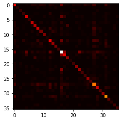

```python
import matplotlib.pyplot as plt

plt.imshow(coocc, cmap='hot', interpolation='nearest')
plt.show()
```

```python
fig = px.imshow(coocc, color_continuous_scale='purd')

fig.show()
```

[interactive chart not shown]

```python
fig = px.imshow(corr, color_continuous_scale='purd')

fig.show()

plotly.offline.plot(fig, filename='./images/correlation.html')
```

[interactive chart not shown]

```
'./images/correlation.html'
```

```python
fig = go.Figure()

#adding correlation map
correlation = fig.add_trace(go.Heatmap(z=corr, x=corr.index, y=corr.index, colorscale="purd"))

#adding Co-concordance map
cooccurrence = fig.add_trace(go.Heatmap(z=coocc, x=coocc.index, y=coocc.index, colorscale="purd"))

#making it a square
fig.update_layout(
    width=800,
    height=800,
     template="plotly_white",)

fig.update_scenes(
    aspectratio=dict(x=1, y=1, z=0.7),
    aspectmode="manual"
)

fig.update_layout(
    updatemenus=[
        dict(
            buttons=list([
                dict(
                    args = [{"visible": [False, True]}],
                    label="Adjacency Matrix",
                    method="restyle"
                ),
                dict(
                    args = [{"visible": [True, False]}],
                    label="Correlation Matrix",
                    method="restyle"
                )
            ]),
            direction="down",
            pad={"r":10, "t": 5},
            showactive=True,
            x=0.1,
            xanchor="right",
            y=1.1,
            yanchor="top"
        ),
    ]
)


plotly.offline.plot(fig, filename='./images/correlation_and_cooccurrence.html')
```

```
'./images/correlation_and_cooccurrence.html'
```